# Initial Data Exploration

Ignasi

25/11/2019

```r
library(biomformat)
library(tidyr)
library(ggplot2)
library(plyr)
library(reactable)
```

On 2019-11-14 I imported the reads into qiime2 and compared the already merged data to the results of merging the clean reads with dada2 in qimme2. I decided to work from the reads that had already been merged by the sequencing services with a program called FLASH. Here the goal is visualize the statistics and main features of the dataset.

# De-noised statistics

Let’s take a look first at the results of the de-noising process.

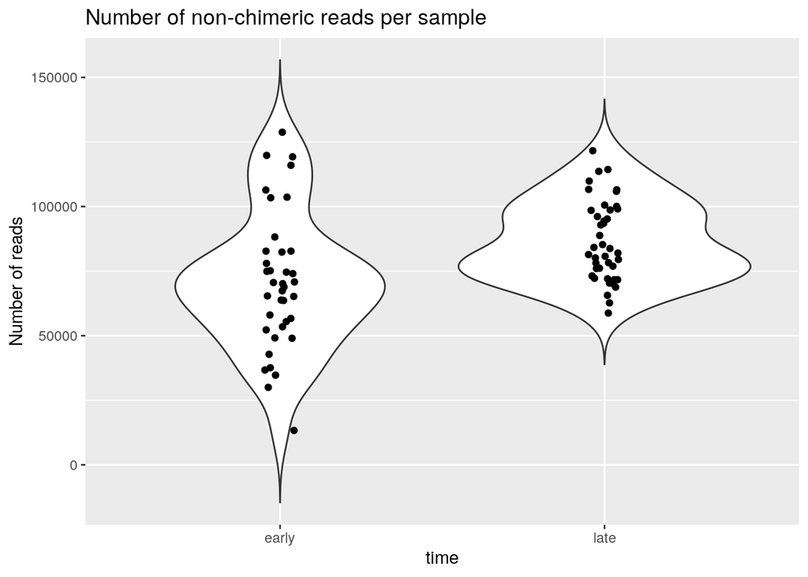

```r
DenoisedStats <- read.table('../2019-11-14/FromMerged/stats.tsv', skip=1,
                            col.names=c('Sample','input','filtered','filtered.p','denoised',
                                        'trusted','trusted.p'),
                            colClasses=c('character', rep('numeric',6)))

DenoisedStats$time <- factor(NA, levels=c('early', 'late'))
DenoisedStats[grep("^E", DenoisedStats$Sample), 'time'] <- 'early'
DenoisedStats[grep("^L", DenoisedStats$Sample), 'time'] <- 'late'
m <- regexpr("[0-9]+", DenoisedStats$Sample)
DenoisedStats$isoline <- as.factor(regmatches(DenoisedStats$Sample, m))
DenoisedStats$excluded <- DenoisedStats$input - DenoisedStats$filtered
DenoisedStats$notDenoised <- DenoisedStats$filtered - DenoisedStats$denoised
DenoisedStats$untrusted <- DenoisedStats$denoised - DenoisedStats$trusted

ggplot(DenoisedStats, mapping=aes(x=time, y=trusted)) + geom_violin(trim=FALSE) + geom_jitter(width=0.05) +
  ggtitle('Number of non-chimeric reads per sample') + ylab('Number of reads')
```

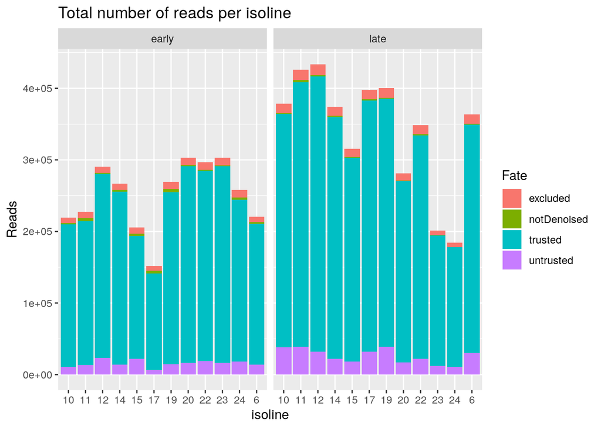

```r
LongStats <- gather(DenoisedStats, key="Fate", value="Reads", c('trusted','untrusted','notDenoised','excluded'))

ggplot(LongStats, mapping=aes(x=isoline, y=Reads, fill=Fate)) + geom_col() + facet_wrap(~time) +
  ggtitle('Total number of reads per isoline')
```

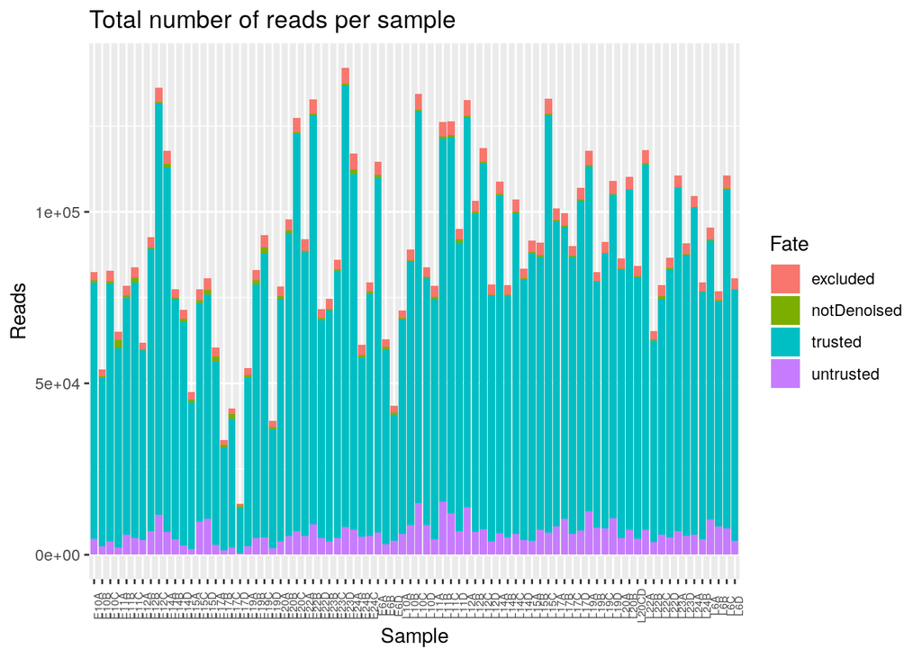

```r
ggplot(LongStats, mapping=aes(x=Sample, y=Reads, fill=Fate)) + geom_col() +
  ggtitle('Total number of reads per sample') + theme(axis.text.x=element_text(angle=90,size=6))
```

```r
rm(list=ls())
```

# Reproduction of qiime’s visualization

The denoising step produced a features table, with the counts of observations of every unique sequence in every sample. That is a rather sparse matrix, with a wide range of values. The visualization `FeatureTable.qzv` can be viewd in [https://view.qiime2.org/]. I can reproduce here some of it. Exporting the table from qiime produced a biom object, which can be loaded in R with the `biomformat` package.

```r
Features <- read_biom('FeatureTable.biom')
# This would not work if the table was too big.
FeatDF <- as.data.frame(as.matrix(biom_data(Features)))
SummTable <- data.frame(Metric=c('Number of samples', 'Number of features', 'Total frequency'),
                        Sample=c(dim(FeatDF)[c(2,1)], sum(FeatDF)))
```

## Table summary

```r
reactable(SummTable, striped=TRUE, highlight=TRUE, columns=list(
  Metric=colDef(style=list(fontWeight='bold')),
  Sample=colDef(format=colFormat(digits=2, separators=TRUE))))
```

| Metric | Sample |
| --- | --- |
| Number of samples | 80 |
| Number of features | 2472 |
| Total frequency | 6320380 |

## Frequency per sample

```r
TotalCountsPerSample <- sapply(FeatDF, sum)
# summary() returns a table object that I cannot coerce into a data.frame without
# turning it first into an array. I take that chance to edit row names.
SummaryTotalCounts   <- data.frame(Frequency = array(summary(TotalCountsPerSample),
                                                     dimnames=list(c('Minimum frequency',
                                                                     '1st quantile',
                                                                     'Median frequency',
                                                                     'Mean frequency',
                                                                     '3rd quantile',
                                                                     'Maximum frequency'))))
reactable(SummaryTotalCounts, striped=TRUE, highlight=TRUE, columns=list(
  Frequency = colDef(format=colFormat(digits=2, separators=TRUE)),
  .rownames = colDef(style=list(fontWeight='bold'))))
```

|  | Frequency |
| --- | --- |
| Minimum frequency | 13313 |
| 1st quantile | 66934.25 |
| Median frequency | 77446 |
| Mean frequency | 79004.75 |
| 3rd quantile | 95425.75 |
| Maximum frequency | 128773 |

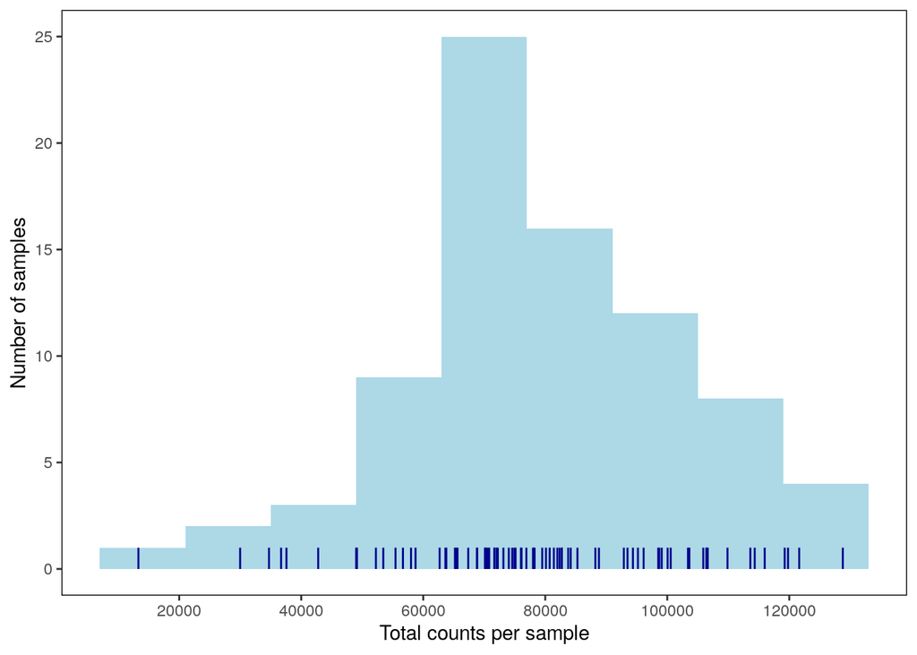

```r
ggplot(data.frame(Freq=TotalCountsPerSample), mapping=aes(x=Freq)) +
  geom_histogram(binwidth=14000, fill='lightblue') +
  scale_x_continuous(breaks=c(20000,40000,60000,80000,100000,120000))+
  geom_segment(aes(xend=Freq), y=0, yend=1, color='darkblue')+
  theme(panel.background=element_rect(fill ='white'),
        panel.border=element_rect(color='black', fill=NA)) +
  xlab('Total counts per sample') +
  ylab('Number of samples')
```

## Frequency per feature

```r
TotalCountsPerFeature <- rowSums(as.matrix(biom_data(Features)))
SummaryTotalCounts   <- data.frame(Frequency = array(summary(TotalCountsPerFeature),
                                                     dimnames=list(c('Minimum frequency',
                                                                     '1st quantile',
                                                                     'Median frequency',
                                                                     'Mean frequency',
                                                                     '3rd quantile',
                                                                     'Maximum frequency'))))
reactable(SummaryTotalCounts, striped=TRUE, highlight=TRUE, columns=list(
  Frequency = colDef(format=colFormat(digits=2, separators=TRUE)),
  .rownames = colDef(style=list(fontWeight='bold'))))
```

|  | Frequency |
| --- | --- |
| Minimum frequency | 2 |
| 1st quantile | 10 |
| Median frequency | 28 |
| Mean frequency | 2556.78802588997 |
| 3rd quantile | 104 |
| Maximum frequency | 196575 |

This histogram of feature’s frequencies uses a log-transformed coordinate, with bins having the same width in un-transformed scale. On the y axis, I use a square root transformation, instead of logarithmic, to preserve bins of frequency 0 or 1.

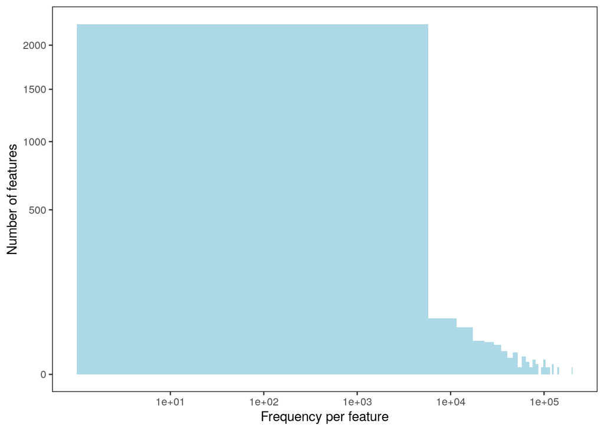

```r
ggplot(data.frame(Freq=TotalCountsPerFeature), mapping=aes(x=Freq)) +
  geom_histogram(fill='lightblue', bins=35, boundary=1) + # prevents Nan upon log transformation
  coord_trans(x='log10') +
  scale_y_sqrt() +
  scale_x_continuous(breaks=c(1e1, 1e2, 1e3, 1e4, 1e5)) +
  theme(panel.background=element_rect(fill='white'),
        panel.border=element_rect(color='black', fill=NA)) +
  xlab('Frequency per feature') +
  ylab('Number of features')
```

It may be better to use an untransformed x axis.

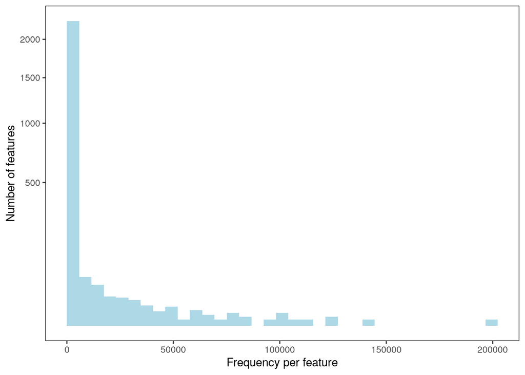

```r
ggplot(data.frame(Freq=TotalCountsPerFeature), mapping=aes(x=Freq)) +
  geom_histogram(fill='lightblue', bins=35, boundary=0) +
  scale_y_sqrt() +
  theme(panel.background=element_rect(fill='white'),
        panel.border=element_rect(color='black', fill=NA)) +
  xlab('Frequency per feature') +
  ylab('Number of features')
```

Let’s zoom in:

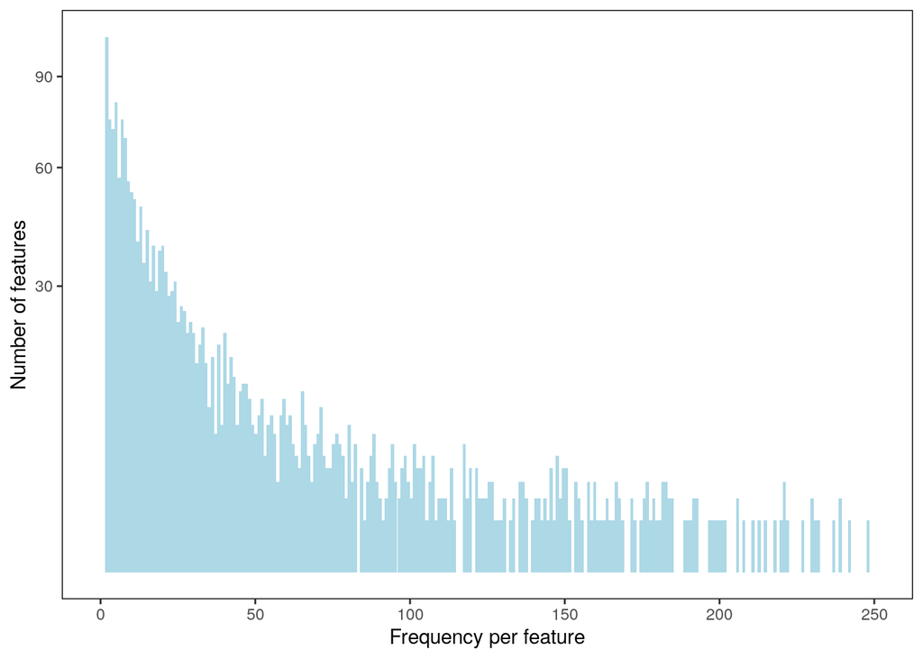

```r
ggplot(data.frame(Freq=TotalCountsPerFeature), mapping=aes(x=Freq)) +
  geom_histogram(fill='lightblue', bins=250, boundary=0.5) +
  scale_y_sqrt() +
  xlim(c(0,250)) +
  theme(panel.background=element_rect(fill='white'),
        panel.border=element_rect(color='black', fill=NA)) +
  xlab('Frequency per feature') +
  ylab('Number of features')
```

The most frequent count is also the lowest: 2 per sample. This means that qiime2 applied dada2 separately on each sample, instead of pooling them. Pooling samples would have increased computation time, but also the power to detect low-frequency amplicons. I suppose it also means that any sequence seen only once (in a sample) is assumed to contain an error, the correction of which turns the sequence into its closest relative. I suspect pooling samples before error correction would prevent the spurious correction of some non-errors. Alternatively, it could just mean that singletons are by default excluded, for they can’t be trusted and probably add too little information.

## Sample detail

```r
reactable(data.frame(SampleID = names(TotalCountsPerSample),
                     FeatureCount = TotalCountsPerSample,
                     row.names=NULL),
          striped = TRUE,
          highlight = TRUE,
          columns = list(
            SampleID = colDef(name = 'Sample ID'),
            FeatureCount = colDef(name = 'Feature Count')))
```

| Sample ID | Feature Count |
| --- | --- |
| E10A | 74927 |
| E10B | 49007 |
| E10C | 75132 |
| E11A | 57997 |
| E11B | 68829 |
| E11C | 74591 |
| E12A | 55458 |
| E12B | 82358 |
| E12C | 119796 |
| E14A | 106395 |

[output cut: 70 more lines]

## Feature detail

```r
NumSamplesIn <- rowSums(FeatDF > 0)
reactable(data.frame(Frequency = TotalCountsPerFeature,
                     NumSamplesIn = NumSamplesIn),
          striped = TRUE,
          highlight = TRUE,
          columns = list(
            Frequency = colDef(format = colFormat(separators=TRUE)),
            NumSamplesIn = colDef(name = '# of Samples Observed In')))
```

|  | Frequency | # of Samples Observed In |
| --- | --- | --- |
| 9a10f3b75201aa351ae3579df29124f0 | 196575 | 78 |
| 6cbb3edac91dc9ef8c7f88ca04fdc9f0 | 143525 | 80 |
| 7b637ec740391c87a1d3a14f3e3a80b8 | 127169 | 78 |
| 3b55546a8514e29db4f5305ef1e88fb6 | 123031 | 78 |
| a42d02345192258bc721f86457593bd0 | 112505 | 80 |
| 380fab01012e7aaa825d78e126ad7dc2 | 107808 | 78 |
| a5f69d3c762d2b8701e97646b335d308 | 100361 | 78 |
| 3d2cba87e034f12f83ee6d80a7208473 | 99430 | 79 |
| 869a681c1209b2acb31374325ce999ec | 99398 | 78 |
| ee0f1dc88ea0ce43a011f5ebd5c87d3e | 98296 | 77 |

[output cut: 2462 more lines]

# Heatmap

We can visualize the whole data matrix as a heatmap. That may give us some insight. Note that I need to summarize the counts from replicates of the same isoline at the same time point. Here, I am plotting the mean count among replicates. I could have used the sum, even though not all isolines are replicated the same number of times. Anyways, the total number of reads per sample is very variable. That is to say I am not using any normalization here.

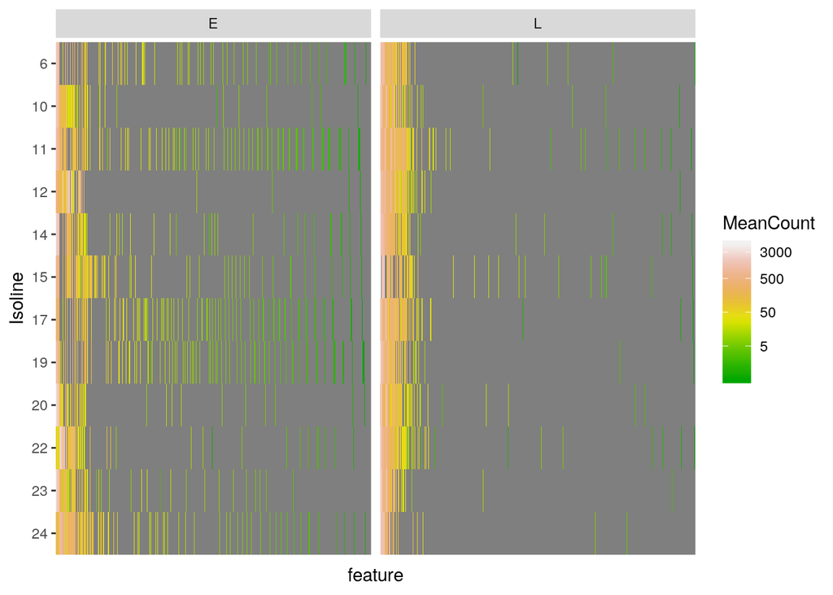

```r
# I want to preserve the order of the features.
FeatDF$feature <- factor(rownames(FeatDF), levels=unique(rownames(FeatDF)), ordered=TRUE)
rownames(FeatDF) <- NULL
LongFeat <- pivot_longer(FeatDF, cols=c(1:80), names_to=c("Age","Isoline","Batch"),
                         names_pattern="([LE])([0-9]+)([A-Z]+)", values_to="Count")
LongFeat$Isoline <- factor(LongFeat$Isoline, levels=c(24,23,22,20,19,17,15,14,12,11,10,6), ordered=TRUE)
SummFeat <- ddply(LongFeat, .variables=c("feature", "Age", "Isoline"), summarize,
                  MeanCount = mean(Count), SDCount=sd(Count))
ggplot(data=SummFeat, mapping=aes(x=feature, y=Isoline, fill=MeanCount)) +
  geom_tile() + facet_wrap(~Age) +
  scale_fill_gradientn(trans='log', colors=terrain.colors(10), breaks=c(5,50,500,3000)) +
  theme(axis.text.x = element_blank(), axis.ticks.x = element_blank())
```

# PCA

Just to add another visualization, this time I do transform abundance to the logarithm of relative frequency. I impute the frequency of unobserved variants in a sample as the overall frequency, just to avoid missing data. There must be better ways. This plot is not to be taken too seriously, but it suggests something weird is happening with samples E11A, E17A and E19C. These are not samples with particularly low overall counts.

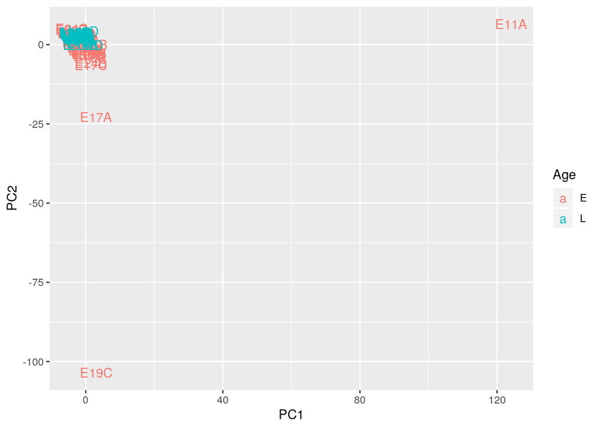

```r
OverallFreq <- rowSums(as.matrix(biom_data(Features)))/sum(as.matrix(biom_data(Features)))
LongFeatTransformed <- ddply(LongFeat,
                             .variables = c('Age','Isoline','Batch'),
                             .fun = function(x) {
                               Freq <- x$Count / sum(x$Count)
                               Freq[Freq == 0] <- OverallFreq[x$feature[Freq == 0]]
                               return(data.frame(
                                 feature = x$feature,
                                 Age = x$Age,
                                 Isoline = x$Isoline,
                                 Batch = x$Batch,
                                 Count = x$Count,
                                 LogFreq = log(Freq)))})
LogFreqDF <- pivot_wider(LongFeatTransformed,
                         id_cols=c('Age','Isoline','Batch'),
                         names_from='feature',
                         values_from='LogFreq')
pca <- prcomp(LogFreqDF[4:2475], retx=TRUE, center=TRUE, scale.=TRUE)
pcaDF <- data.frame(Age = LogFreqDF$Age,
                    Isoline = LogFreqDF$Isoline,
                    Name = paste(LogFreqDF$Age, LogFreqDF$Isoline, LogFreqDF$Batch, sep=''),
                    pca$x)
ggplot(pcaDF, mapping=aes(x=PC1, y=PC2, color=Age)) + geom_text(aes(label=Name))
```